# Comparing differential expression of predicted transcripbed instergenic regions

Amanda Yeo, Hernan Lorenzi, Orna Cohen-Fix

2023-12-19

### Install required packages

```r
### Install required R libraries/packages:

# CRAN repository:
required_cran_packages <- c("cowplot", "ggpubr", "ggsci", "RColorBrewer", "pheatmap",
    "ashr")
new_cran_packages <- required_cran_packages[!(required_cran_packages %in% installed.packages()[,
    "Package"])]
if (length(new_cran_packages) > 0) {
    install.packages(new_cran_packages)
}

# Bioconductor repository:
required_bioconductor_packages <- c("DESeq2", "org.Sc.sgd.db", "EnhancedVolcano",
    "enrichplot", "clusterProfiler")

new_bioconductor_packages <- required_bioconductor_packages[!(required_bioconductor_packages %in%
    installed.packages()[, "Package"])]

if (length(new_bioconductor_packages) > 0) {
    if (!require("BiocManager", quietly = TRUE)) {
        install.packages("BiocManager")
    }
    BiocManager::install(new_bioconductor_packages)
}
```

### Load R libraries

```r
# Packages for differential expression analysis and plotting:

suppressWarnings(
  suppressPackageStartupMessages({
    library(DESeq2);  # Package for differential expression analysis
    library(cowplot); # Package for saving plots (ggsave2)
    library(ggpubr); # Package for plotting functions
    library(ggsci);
    library(RColorBrewer);
    library(pheatmap); # Package for volcane plot functions
    library(org.Sc.sgd.db); # Yeast annotations
    library(EnhancedVolcano);
    library(clusterProfiler);
    library(enrichplot);
    }
  )
)
```

### Load useful functions

```r
#
# --- function for adding gene names to DESeq2 result table ---
#
get_gene_names_from_gene_ids <- function(ensemble_ids, annotation_db,
                                         look_for = 'ENSEMBL',
                                         fetch = 'GENENAME', return_all = TRUE){
  # Reference organism: Saccharomyces cerevisiae => DATABASE = org.Sc.sgd.db
  symbols <- mapIds(annotation_db, keys = ensemble_ids, column = fetch,
                    keytype = look_for, multiVals = "first")
  symbols <- symbols[!is.na(symbols)]
  to_name <- ensemble_ids %in% names(symbols)
  ensemble_ids[to_name] <- as.vector(symbols)

  if (return_all){
    return(unlist(lapply(ensemble_ids, function(x){if(is.null(x)){x="NA"}else{x=x}})))
  }
  else {
    return(ensemble_ids[to_name])
  }
}

#
# --- function for PCA plots ---
#
plot_PCA = function(object, color_by="condition",
                    shape_by = 19, ntop=500, size = 3,
                    returnData=FALSE, pcs = c(1,2))
{
  # Check variables are present in object
  intgroup = c(color_by)
  if (shape_by != 19){intgroup <- c(intgroup, shape_by)}
  if (!all(intgroup %in% names(colData(object)))) {
    stop("the argument 'intgroup' should specify columns of colData(dds)")
  }

  # calculate the variance for each gene
  rv <- rowVars(assay(object))

  # select the ntop genes by variance
  select <- order(rv, decreasing=TRUE)[seq_len(min(ntop, length(rv)))]

  # perform a PCA on the data in assay(x) for the selected genes
  pca <- prcomp(t(assay(object)[select,]))

  # the contribution to the total variance for each component
  percentVar <- pca$sdev^2 / sum( pca$sdev^2 )


  intgroup.df <- as.data.frame(colData(object)[, intgroup, drop=FALSE])

  # add the intgroup factors together to create a new grouping factor
  group <- if (length(intgroup) > 1) {
    factor(apply( intgroup.df, 1, paste, collapse=":"))
  } else {
    colData(object)[[intgroup]]
  }

  # assembly the data for the plot
  d <- data.frame(PC1=pca$x[,pcs[1]], PC2=pca$x[,pcs[2]], group=group, intgroup.df, name=colnames(object))
  colnames(d)[1] <- paste0("PC",pcs[1])
  colnames(d)[2] <- paste0("PC",pcs[2])

  if (returnData) {
    attr(d, "percentVar") <- percentVar[1:2]
    return(d)
  }

  ggplot(data=d, aes_string(x=colnames(d)[1], y=colnames(d)[2], color=color_by, shape=shape_by)) +
    geom_point(size=size) +
    scale_color_lancet() +
    xlab(paste0("PC",pcs[1],": ",round(percentVar[pcs[1]] * 100),"% variance")) + # fixed
    ylab(paste0("PC",pcs[2],": ",round(percentVar[pcs[2]] * 100),"% variance")) + # fixed
    coord_fixed(ratio = (max(d[,1])-min(d[,1]))/(max(d[,2])-min(d[,2])))
}

#
# --- function to plot gene expression of top10 genes ---
#
# Plot top10 diff expressed genes
plot_expression_topN_genes <- function(deseq_result, N=10){
  my_top10 <- head(rownames(deseq_result),N)
  for (gene in my_top10){
    print(gene)
    #plotCounts(dds, gene,
    #           intgroup = c("treatment","genotype"),
    #           returnData = FALSE, col=metadata$genotype)
  }
}

draw_enrichment_network<- function(dds_res, my_enricher_obj,
                                    my_pathway_counts = 400,
                                    file_name_prefix = "enricher_dotplot",
                                    my_width = 11,
                                    my_height = 8,
                                    padj_cutoff = 0.05){

  # Save Log2FC vals in log2fc_symb.df
  log2fc_symb.df <- dplyr::select(as.data.frame(dds_res),
                           c("log2FoldChange","padj"))

  log2fc_symb.df$symbols <- get_gene_names_from_gene_ids(
                            ensemble_ids = rownames(log2fc_symb.df),
                            annotation_db = org.Sc.sgd.db,                                               look_for = "ENSEMBL",                                                        fetch = "GENENAME",                                                          return_all = TRUE)

  # Filter results by p.adjust values
  my_enricher_obj@pvalueCutoff <- padj_cutoff
  my_enricher_obj@qvalueCutoff <- padj_cutoff

  distance_matrix <- pairwise_termsim(my_enricher_obj,
                                      showCategory = my_pathway_counts)

  # Get median Log2FC per identified pathway
  my_median_log2fc <- c()

  for (g in distance_matrix@result$geneID){
    g.vec <- strsplit(g, "/")[[1]]
    log2fc.median <- median(subset(log2fc_symb.df, rownames(log2fc_symb.df) %in% g.vec)[,"log2FoldChange"])
    my_median_log2fc <- c(my_median_log2fc,log2fc.median)
  }

  # Add median Log2FC column
  if(length(my_median_log2fc) == 0){my_median_log2fc <- 0}
  distance_matrix@result$median.log2fc <- my_median_log2fc

  # Network plot
  p6 <- emapplot(distance_matrix,
                 repel = T,
                 showCategory = my_pathway_counts,
                 legend_n = 5,
                 min_edge = 0.4 ,
                 color = "median.log2fc",
                 cex_label_category = 0.4,
                 node_label = "category",
                 label_format = 20)



  print(p6)

  ggsave2(filename = paste0(file_name_prefix,"_network_OA.pdf"),
          plot = p6, width = my_width, height = my_height)

  return(p6)
}

draw_enrichment_tree<- function(dds_res, my_enricher_obj,
                                  my_pathway_counts = 400,
                                  file_name_prefix = "enricher_dotplot",
                                  my_width = 11,
                                  my_height = 8,
                                  padj_cutoff = 0.05){

  # Save Log2FC vals in log2fc_symb.df
  log2fc_symb.df <- dplyr::select(as.data.frame(dds_res), c("log2FoldChange","padj"))

  log2fc_symb.df$symbols <- get_gene_names_from_gene_ids(
                              ensemble_ids = rownames(log2fc_symb.df),
                              annotation_db = org.Sc.sgd.db,
                              look_for = "ENSEMBL",
                              fetch = "GENENAME",
                              return_all = TRUE)

  # Filter results by p.adjust values
  my_enricher_obj@pvalueCutoff <- padj_cutoff
  my_enricher_obj@qvalueCutoff <- padj_cutoff

  distance_matrix <- pairwise_termsim(my_enricher_obj, showCategory = my_pathway_counts)

  # Get median Log2FC per identified pathway
  my_median_log2fc <- c()

  for (g in distance_matrix@result$geneID){
    g.vec <- strsplit(g, "/")[[1]]
    log2fc.median <- median(subset(log2fc_symb.df, rownames(log2fc_symb.df) %in% g.vec)[,"log2FoldChange"])
    my_median_log2fc <- c(my_median_log2fc,log2fc.median)
  }

  # Add median Log2FC column
  if(length(my_median_log2fc) == 0){my_median_log2fc <- 0}
  distance_matrix@result$median.log2fc <- my_median_log2fc

  # Treeplots
  number_of_categories = min(80, as.vector(table(distance_matrix@result$p.adjust < 0.05)[['TRUE']]))
  p7 <- treeplot(distance_matrix,
                showCategory = 80,
                nCluster = round(2 * sqrt(number_of_categories),
                                 digits = 0),
                color = "median.log2fc",
                nWords = 0)



  print(p7)

  ggsave2(filename = paste0(file_name_prefix,"_tree_OA.pdf"),
          plot = p7, width = my_width, height = my_height)

  return(p7)
}

add_flanking_genes <- function(summary_table){
  if ('Row.names' %in% colnames(summary_table)){
    tmp_table <- merge(x = summary_table, y = id2genes, by.x = 'Row.names', by.y = 'gene_id', all.x = TRUE)
  } else {
    tmp_table <- merge(x = summary_table, y = id2genes, by.x = 'row.names', by.y = 'gene_id', all.x = TRUE)
  }
  row.names(tmp_table) <- tmp_table$Row.names
  tmp_table$up_gene_name <- get_gene_names_from_gene_ids(ensemble_ids = tmp_table$gene_id_up, annotation_db = org.Sc.sgd.db, look_for = 'ENSEMBL', fetch = "GENENAME", return_all = TRUE)
  tmp_table$down_gene_name <- unlist(get_gene_names_from_gene_ids(ensemble_ids = tmp_table$gene_id_down, annotation_db = org.Sc.sgd.db, look_for = 'ENSEMBL', fetch = "GENENAME", return_all = TRUE))

  return(tmp_table)
}

# Function to normalize by TPMs based on transcript length
# Normalize counts to TPMs
# Fetch exon length from STAR read counts file
normalize_by_TPM <- function(counts.df, gene_length) {

  # Calculate transcript length in Kb
  transcript_lengths <- gene_length / 1000
  transcript_lengths <- subset(transcript_lengths, rownames(transcript_lengths) %in% rownames(counts.df))

  # Eliminate gene IDs from counts.df without transcript length info in transcript_lengths
  #transcript_lengths <- transcript_lengths[transcript_lengths$Category %in% rownames(counts.df),]
  #counts.df <- counts.df[transcript_lengths$Category,]

  # Sort transcripts_length df by rownames of counts.df
  transcript_lengths <- transcript_lengths[rownames(counts.df),, drop=F]

  # See reference for formula
  # https://bioinformatics.ccr.cancer.gov/btep/questions/what-is-the-difference-between-rpkm-fpkm-and-tpm
  x.df <- apply(counts.df,
                MARGIN = 2,
                FUN = function(x){
                                  reads_per_kb <- x/transcript_lengths$Length
                                  pmsf <- sum(reads_per_kb) / 1e6
                                  reads_per_kb/pmsf
                                  }
                )

  return(x.df)
}
```

### Load data

Hernan’s code below: Basically the same as Amanda’s but loads read counts and metadata for all samples and then split the tables into genotype-specific input files.

```r
# Import read counts table into read_counts variable
read_counts.star <- read.table(file = "./data/read_counts_aymerge.txt",
                          header = TRUE, # First line contains column headers
                          row.names = 1, # Column 1 contains row names
                          sep = "\t")   # Column delimiter is a tab (\t)

# Remove star info columns [1..5]
read_counts.all <- read_counts.star[,-c(1:5)]

colnames(read_counts.all) <- names(read_counts.all) %>%
                              stringr::str_remove_all(pattern="..BAM.|_S[0-9]+_L[0-9]+.sorted.dedup.bam")

# Round read counts to the closest integer
read_counts.all <- round(read_counts.all, digits = 0)

# Read metadata.all table
metadata.all <- read.table(file = "./data/metadata_OC8901vsOC8345.txt",
                       header = TRUE,
                       row.names = 1,
                       sep = "\t")

# Sort read_counts.all table so metadata.all and read_counts.all match order
read_counts.all <- dplyr::select(read_counts.all, rownames(metadata.all))

# Include sample ids in metadata.all as a variable (column)
metadata.all$sample_id <- rownames(metadata.all)

# Include total read counts in metadata.all
metadata.all$read_counts <- colSums(read_counts.all, na.rm = TRUE)

# Make group, strain, treatment and genotype columns as factors
metadata.all$treatment <- as.factor(metadata.all$treatment)
metadata.all$strain <- as.factor(metadata.all$strain)
metadata.all$genotype <- as.factor(metadata.all$genotype)
metadata.all$experiment <- as.factor(metadata.all$experiment)

## Load flanking gene data
id2genes <- read.table(file = "./data/FLANKING_GENES/aymerge.no_LTR.NO_ref_genes.flanking.txt", header = T, sep = "\t")
# remove duplicated rows
id2genes <- id2genes[!duplicated(id2genes$gene_id),]
```

### Keep WT simples

```r
# Keep only WT-specific data to match Amanda's code inputs
keep <- metadata.all$genotype == "wt"
metadata <- metadata.all[keep, ]
read_counts <- read_counts.all[, keep]
```

### DE analysis with DESeq2

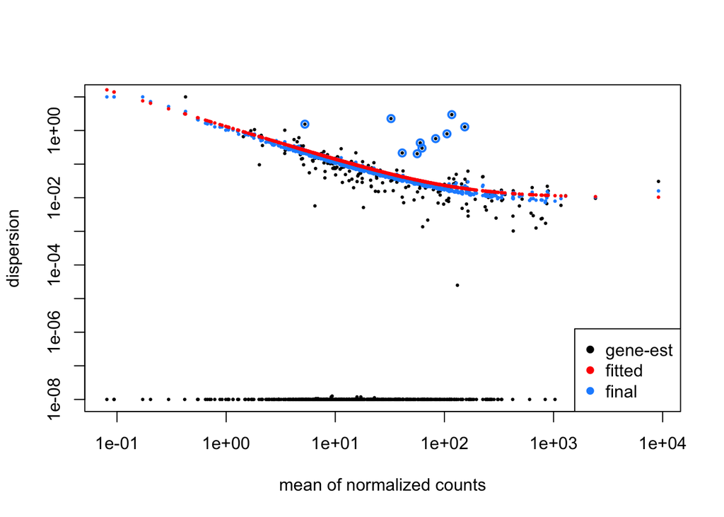

```r
# Create folder for storing plots
mapper <- "no_multimapper"
plot_path <- paste0("./", mapper, "/Plots_intergenic_wt")
DE_path <- paste0("./", mapper, "/DE_intergenic_wt")
dir.create(path = plot_path, showWarnings = FALSE, recursive = TRUE)
dir.create(path = DE_path, showWarnings = FALSE, recursive = TRUE)

# Add extra metadata column with treatment and genotype data combined
metadata$treat_geno <- paste(metadata$treatment, metadata$genotype, sep = "_")

# Create DESeq2 object
dds <- DESeqDataSetFromMatrix(countData = read_counts, colData = metadata, design = ~experiment +
    treat_geno)  # Here we assume that all genotypes respond the same to treatment


# Make sure reference groups are 'none' and 'wt'. This means those categories
# will be the denominator when calculating Log2FC.
dds$treatment <- relevel(dds$treatment, "none")
# dds$genotype <- relevel(dds$genotype, 'wt')
dds$treat_geno <- relevel(dds$treat_geno, "none_wt")
dds <- DESeq(dds)

plotDispEsts(dds)
```

### Explortory analysis #1

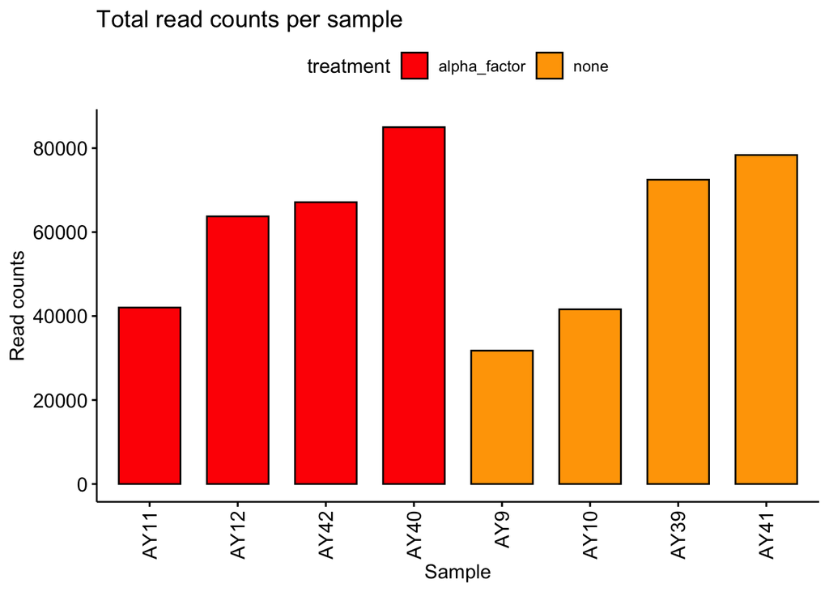

```r
# Plot total reads per sample using barchar
readcounts.p <- ggbarplot(data = metadata,
                x = "sample_id",
                y = "read_counts",
                x.text.angle = 90,
                fill = "treatment",
                title = "Total read counts per sample",
                ylab = "Read counts",
                sort.by.groups = TRUE,
                palette = c("red","orange"), #"jco",
                sort.val = "asc") + xlab("Sample") + ylab("Read counts")
ggsave2("barplot_read_counts_per_sample_intergenic.pdf", plot = readcounts.p, path = plot_path)

print(readcounts.p)
```

**Figure 1:** Number of reads per sample

### Preprocess data stored in DESeq2 object dds

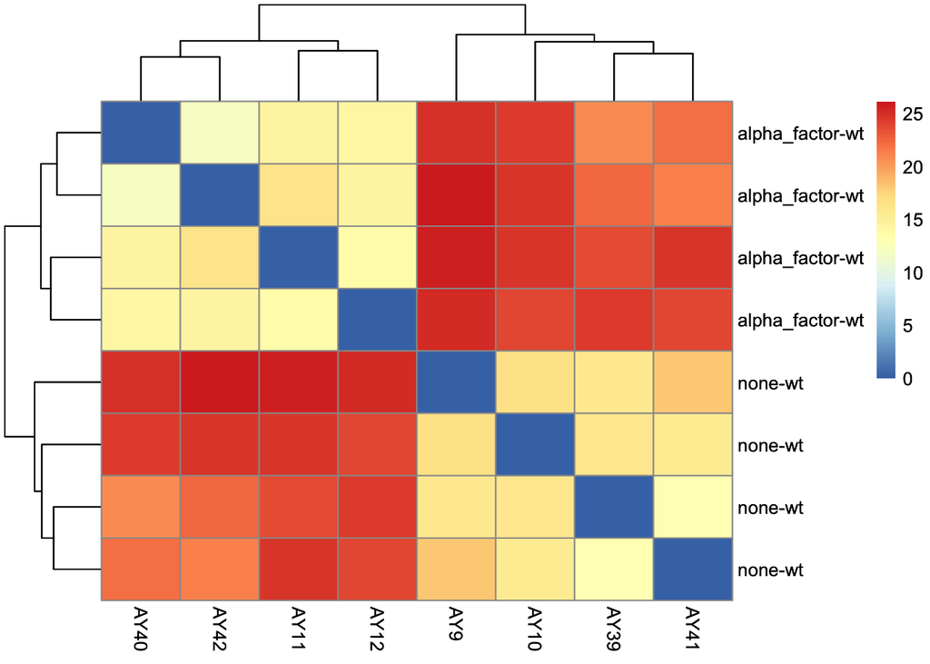

```r
# 1. Normalize counts dds.vst <- vst(dds, blind=TRUE) error in vst(dds, blind =
# TRUE, nsub = 683) : less than 'nsub' rows with mean normalized count > 5, it
# is recommended to use varianceStabilizingTransformation directly
dds.vst <- varianceStabilizingTransformation(dds, blind = TRUE, fitType = "parametric")

# dds.vst <- varianceStabilizingTransformation(dds) # vst(dds, blind=TRUE)
# gives an error due to too few rows (<1000 in dds object)

# 2. Keep genes with at least 10 reads total across all samples
keep <- rowSums(as.data.frame(dds.vst@assays@data@listData)) >= 10
dds.vst <- dds.vst[keep, ]

# 3. Calculate distances between samples
sampleDists <- dist(t(assay(dds.vst)))

# 4. Plot inter-sample distances
sampleDistMatrix <- as.matrix(sampleDists)
rownames(sampleDistMatrix) <- paste(rownames(sampleDistMatrix), dds.vst$treatment)

# colnames(sampleDistMatrix) <- NULL
hm.p <- pheatmap(mat = sampleDistMatrix, clustering_distance_rows = sampleDists,
    clustering_distance_cols = sampleDists, labels_row = paste(metadata$treatment,
        metadata$genotype, sep = "-"), labels_col = metadata$sample_id)

ggsave2(filename = "heat_map_intergenc.pdf", plot = hm.p, path = plot_path)

print(hm.p)
```

**Figure 2:** wt samples cluster by treatment.

### PCA

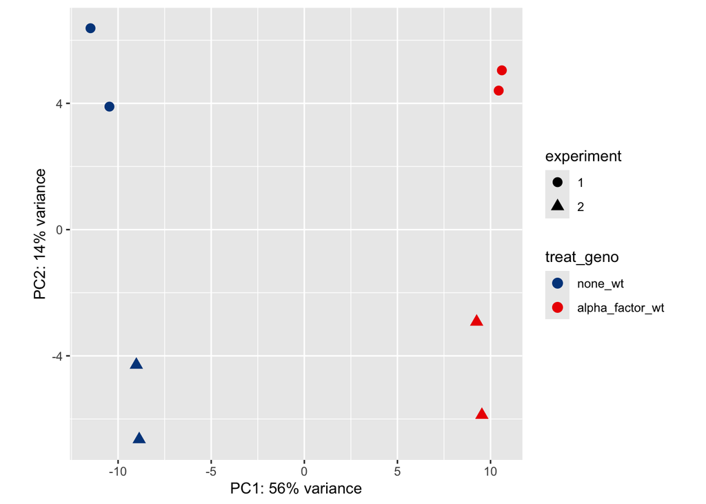

```r
# PCA
principal_components <- c(1, 2)
pca.p <- plot_PCA(object = dds.vst, ntop = 500, color_by = "treat_geno", shape_by = "experiment",
    pcs = principal_components, returnData = FALSE)

ggsave(paste("pca_by_group_PC", principal_components[1], principal_components[2],
    "_intergenic.pdf"), plot = pca.p, path = plot_path)
print(pca.p)
```

**Figure 3:** Samples group mainly by alpha factor treatment (PC1), but is seems there is a batch effect based on experiment number (PC2).

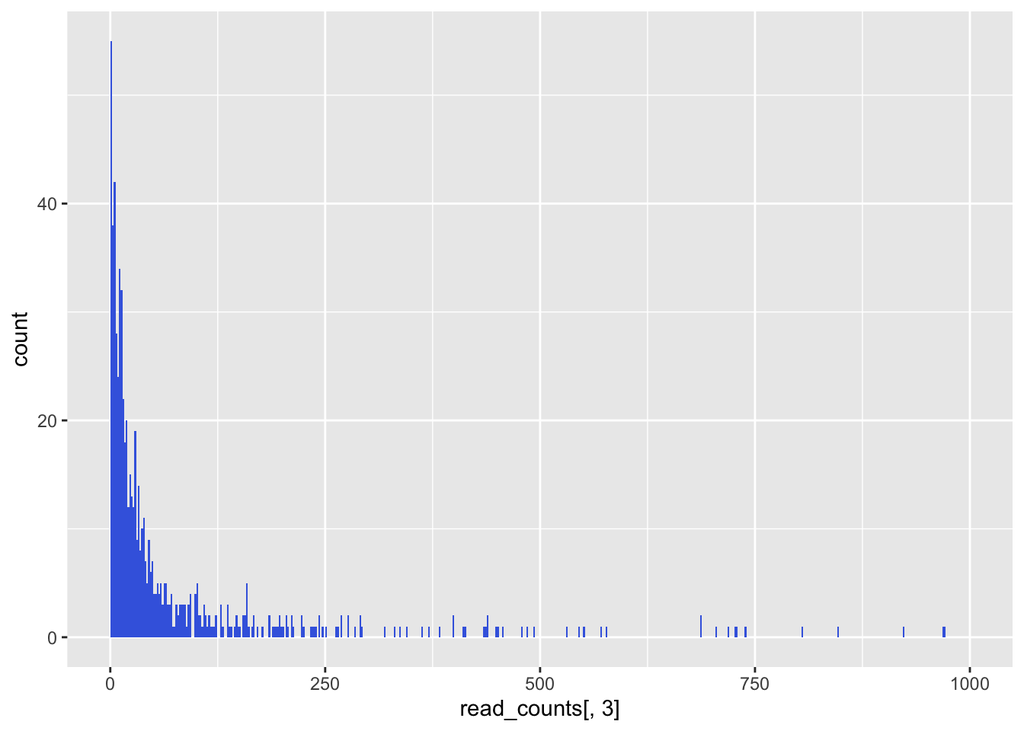

```r
ggplot(read_counts, aes(x = read_counts[, 3])) + geom_histogram(binwidth = 2, fill = "Royalblue",
    boundary = 0) + xlim(0, 1000)
```

**Figure 4:** Read counts per intergenic region follows a negative binomial distribution.

### Print DESeq2 coefficients

```r
print(resultsNames(dds))
```

```
## [1] "Intercept"
## [2] "experiment_2_vs_1"
## [3] "treat_geno_alpha_factor_wt_vs_none_wt"
```

### Differential expression analysis -wt:

**1- The effect of treatment across all wt samples (the main effect)**

*Note: For additional information about different ways of extracting results from a DESeq object see results() function help by typing ?results in the console,*

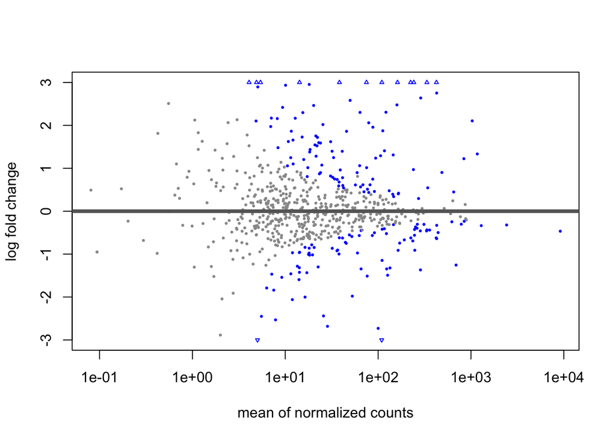

```r
# Create results directory where to store result tables
DE_results_list <- list()
coef <- c("treat_geno_alpha_factor_wt_vs_none_wt")

# Set coef_id with the DESeq2 coefficient of interest
coef_id <- "af_vs_none_wt"

# Get DESeq2 results. Note that when using coefficient names, you have to
# convert the coef vector to a list by doing list(c(coef))
DE_results <- results(dds, contrast = list(c(coef)))


plotMA(DE_results, ylim = c(-3, 3))
```

**Figure 5:** MA plot before shrinkage

```r
# Shrink Log2FC of genes with low expression
DE_results <- lfcShrink(dds, contrast = list(c(coef)), type = "ashr", res = DE_results)

# Sort table by adjusted p,value (ascending)
DE_results <- DE_results[order(DE_results$padj), ]


# Store results table into DE_results list
DE_results_list[[coef_id]] <- DE_results

# Plot top10 diff expressed genes
plot_expression_topN_genes(DE_results_list[[coef_id]], N = 20)
```

```
## [1] "MSTRG.81"
## [1] "MSTRG.548"
## [1] "MSTRG.490"
## [1] "MSTRG.399"
## [1] "MSTRG.65"
## [1] "MSTRG.403"
## [1] "MSTRG.235"
## [1] "MSTRG.124"
## [1] "MSTRG.8"
## [1] "MSTRG.82"
## [1] "MSTRG.676"
## [1] "MSTRG.377"
## [1] "MSTRG.581"
## [1] "MSTRG.7"
## [1] "MSTRG.471"
## [1] "MSTRG.646"
## [1] "MSTRG.610"
## [1] "MSTRG.539"
## [1] "MSTRG.334"
## [1] "MSTRG.435"
```

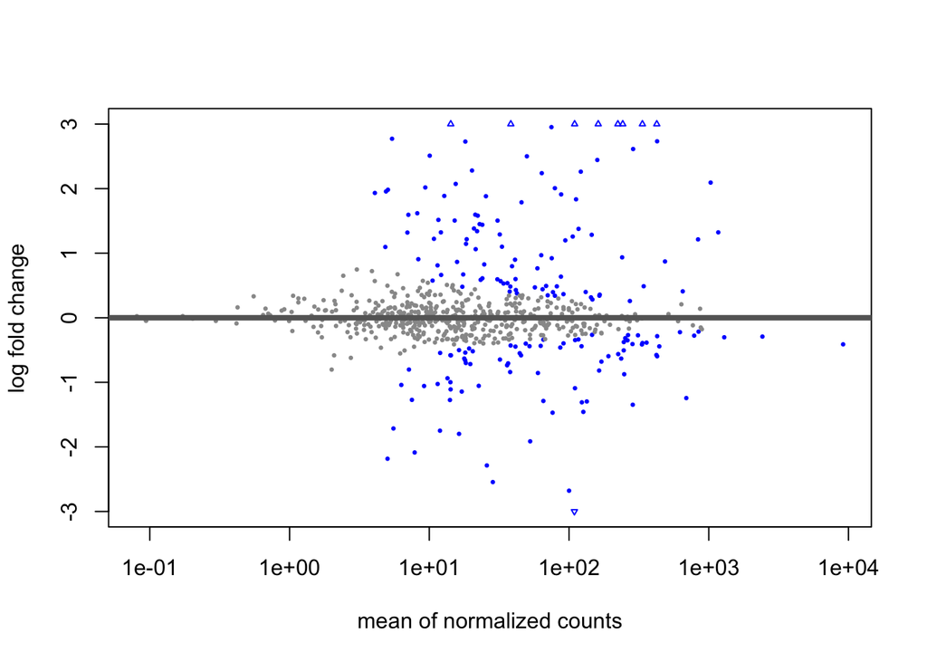

```r
plotMA(DE_results, ylim = c(-3, 3))
```

```r
summary(DE_results, alpha = 0.05)
```

```
##
## out of 681 with nonzero total read count
## adjusted p-value < 0.05
## LFC > 0 (up)       : 89, 13%
## LFC < 0 (down)     : 71, 10%
## outliers [1]       : 0, 0%
## low counts [2]     : 53, 7.8%
## (mean count < 3)
## [1] see 'cooksCutoff' argument of ?results
## [2] see 'independentFiltering' argument of ?results
```

```r
# Add gene names to genes flanking intergenic regions
DE_results <- add_flanking_genes(summary_table = as.data.frame(DE_results))

DE_results_list[[coef_id]] <- DE_results
```

**Figure 6:** MA plot after shrinkage

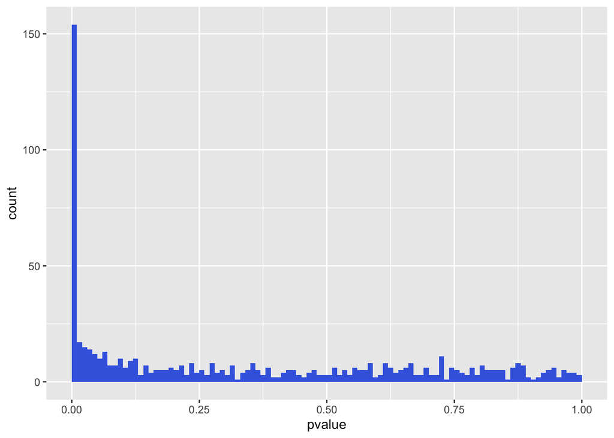

```r
ggplot(as(DE_results, "data.frame"), aes(x = pvalue)) + geom_histogram(binwidth = 0.01,
    fill = "Royalblue", boundary = 0)
```

**Figure 7:** distribution of pvalues from DE results

### Save tables with results stored in the DE_results_list object

```r
for (example_name in names(DE_results_list)) {
    # Save results table into a file
    write.table(x = as.data.frame(DE_results_list[[coef_id]]), file = paste0(DE_path,
        "/DE_", coef_id, ".txt"), sep = "\t", col.names = NA)
}
```

# kar4

### Keep kar4 simples

```r
# Keep only WT-specific data to match Amanda's code inputs
keep <- metadata.all$genotype == "kar4"
metadata <- metadata.all[keep, ]
read_counts <- read_counts.all[, keep]
```

### DE analysis with DESeq2

```r
# Create folder for storing plots
plot_path <- paste0("./", mapper, "/Plots_intergenic_kar4")
DE_path <- paste0("./", mapper, "/DE_intergenic_kar4")
dir.create(path = plot_path, showWarnings = FALSE, recursive = TRUE)
dir.create(path = DE_path, showWarnings = FALSE, recursive = TRUE)

# Add extra metadata column with treatment and genotype data combined
metadata$treat_geno <- paste(metadata$treatment, metadata$genotype, sep = "_")

# Create DESeq2 object
dds <- DESeqDataSetFromMatrix(countData = read_counts, colData = metadata, design = ~experiment +
    treat_geno)  # Here we assume that all genotypes respond the same to treatment


# Make sure reference groups are 'none' and 'wt'. This means those categories
# will be the denominator when calculating Log2FC.
dds$treatment <- relevel(dds$treatment, "none")
# dds$genotype <- relevel(dds$genotype, 'wt')
dds$treat_geno <- relevel(dds$treat_geno, "none_kar4")
dds <- DESeq(dds)
```

### Explortory analysis #1

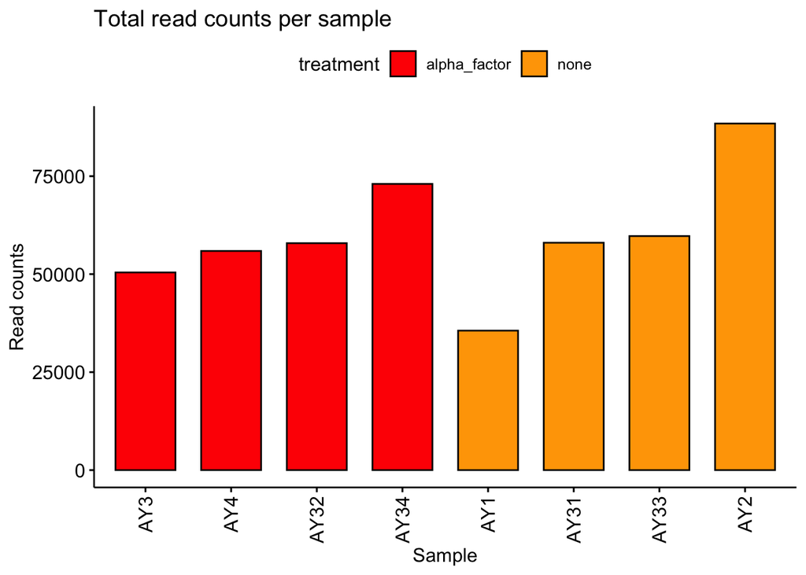

```r
# Plot total reads per sample using barchar
readcounts.p <- ggbarplot(data = metadata,
                x = "sample_id",
                y = "read_counts",
                x.text.angle = 90,
                fill = "treatment",
                title = "Total read counts per sample",
                ylab = "Read counts",
                sort.by.groups = TRUE,
                palette = c("red","orange"), #"jco",
                sort.val = "asc") + xlab("Sample") + ylab("Read counts")
ggsave2("barplot_read_counts_per_sample_intergenic.pdf", plot = readcounts.p, path = plot_path)

print(readcounts.p)
```

**Figure 1:** Number of reads per sample

### Preprocess data stored in DESeq2 object dds

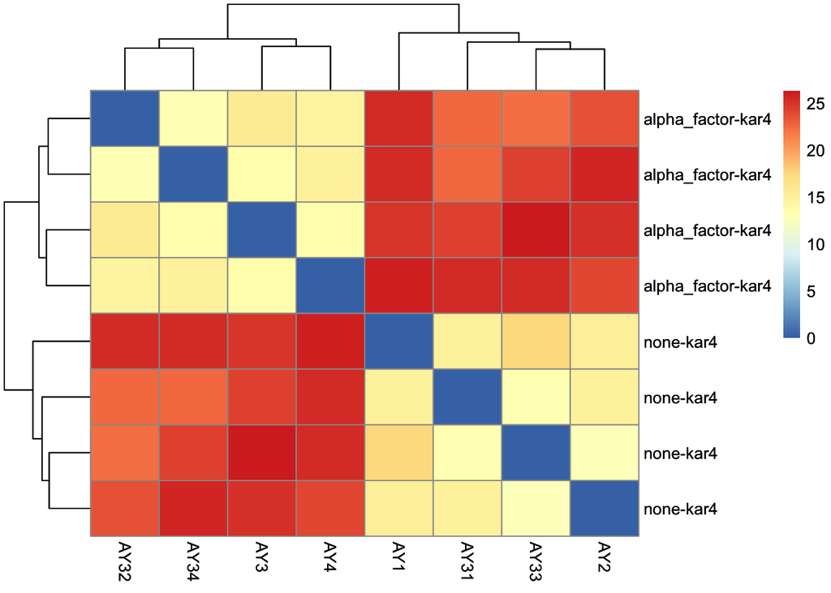

```r
# 1. Normalize counts dds.vst <- vst(dds, blind=TRUE)
dds.vst <- varianceStabilizingTransformation(dds)  # vst(dds, blind=TRUE) gives an error due to too few rows (<1000 in dds object)

# 2. Keep genes with at least 10 reads total across all samples
keep <- rowSums(as.data.frame(dds.vst@assays@data@listData)) >= 10
dds.vst <- dds.vst[keep, ]

# 3. Calculate distances between samples
sampleDists <- dist(t(assay(dds.vst)))

# 4. Plot inter-sample distances
sampleDistMatrix <- as.matrix(sampleDists)
rownames(sampleDistMatrix) <- paste(rownames(sampleDistMatrix), dds.vst$treatment)

# colnames(sampleDistMatrix) <- NULL
hm.p <- pheatmap(mat = sampleDistMatrix, clustering_distance_rows = sampleDists,
    clustering_distance_cols = sampleDists, labels_row = paste(metadata$treatment,
        metadata$genotype, sep = "-"), labels_col = metadata$sample_id)

ggsave2(filename = "heat_map_intergenc.pdf", plot = hm.p, path = plot_path)

print(hm.p)
```

### PCA

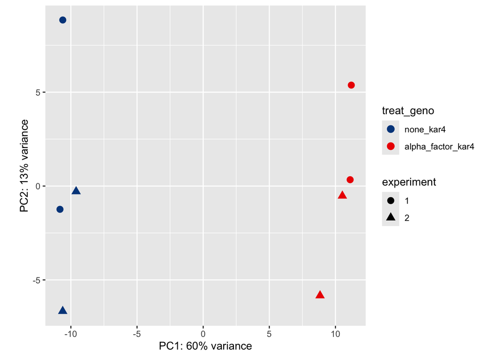

```r
# PCA
principal_components <- c(1, 2)
pca.p <- plot_PCA(object = dds.vst, ntop = 500, color_by = "treat_geno", shape_by = "experiment",
    pcs = principal_components, returnData = FALSE)

ggsave(paste("pca_by_group_PC", principal_components[1], principal_components[2],
    "_intergenic.pdf"), plot = pca.p, path = plot_path)
print(pca.p)
```

**Figure 3:** Samples group mainly by alpha factor treatment (PC1), but is seems there is a batch effect based on experiment number (PC2).

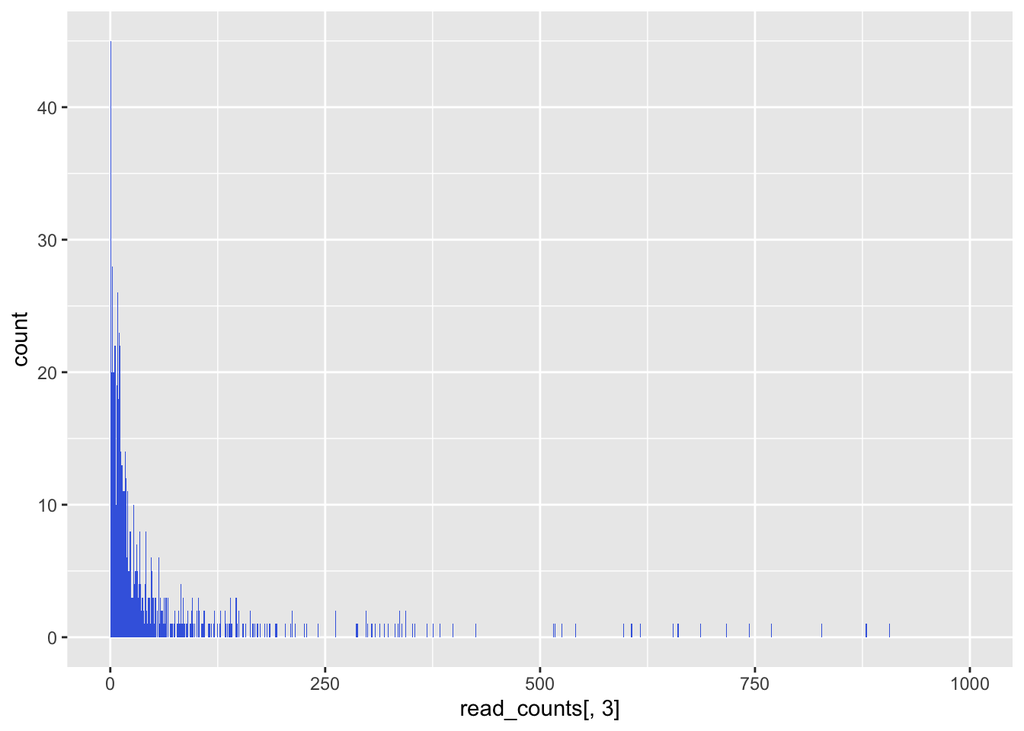

```r
ggplot(read_counts, aes(x = read_counts[, 3])) + geom_histogram(binwidth = 1, fill = "Royalblue",
    boundary = 0) + xlim(0, 1000)
```

**Figure 4:** Read counts per intergenic region follows a negative binomial distribution.

### Print DESeq2 coefficients

```r
print(resultsNames(dds))
```

```
## [1] "Intercept"
## [2] "experiment_2_vs_1"
## [3] "treat_geno_alpha_factor_kar4_vs_none_kar4"
```

*Note: For additional information about different ways of extracting results from a DESeq object see results() function help by typing ?results in the console,*

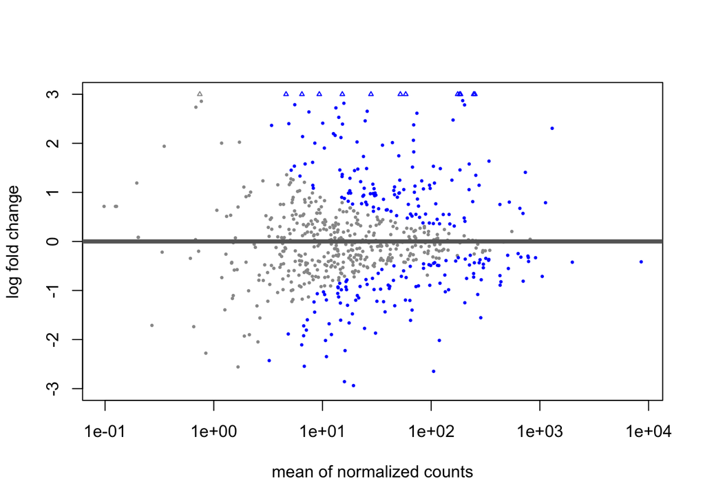

```r
# Create results directory where to store result tables
coef <- c("treat_geno_alpha_factor_kar4_vs_none_kar4")

# Set coef_id with the DESeq2 coefficient of interest
coef_id <- "af_vs_none_kar4"

# Get DESeq2 results. Note that when using coefficient names, you have to
# convert the coef vector to a list by doing list(c(coef))
DE_results <- results(dds, contrast = list(c(coef)))


plotMA(DE_results, ylim = c(-3, 3))
```

**Figure 5:** MA plot before shrinkage

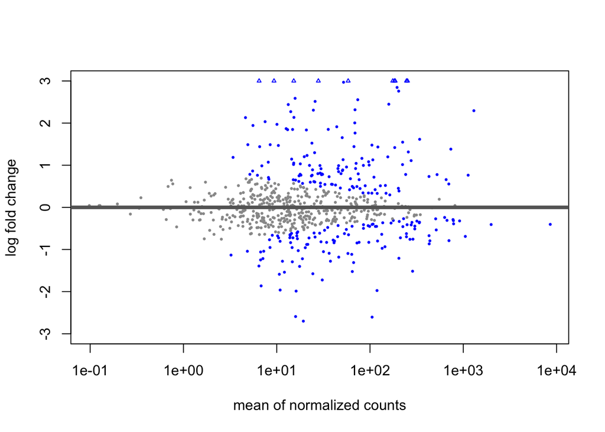

```r
# Shrink Log2FC of genes with low expression
DE_results <- lfcShrink(dds, contrast = list(c(coef)), type = "ashr", res = DE_results)

# Sort table by adjusted p,value (ascending)
DE_results <- DE_results[order(DE_results$padj), ]

plotMA(DE_results, ylim = c(-3, 3))
```

```r
# Add gene names to results table DE_results$gene_names <-
# get_gene_names_from_gene_ids(ensemble_ids = rownames(DE_results),
# annotation_db = org.Sc.sgd.db, look_for = 'ENSEMBL', fetch = 'GENENAME') Add
# gene names to genes flanking intergenic regions
DE_results <- add_flanking_genes(summary_table = as.data.frame(DE_results))

# Store results table into DE_results list
DE_results_list[[coef_id]] <- DE_results

# Plot top10 diff expressed genes
plot_expression_topN_genes(DE_results_list[[coef_id]], N = 20)
```

```
## [1] "MSTRG.1"
## [1] "MSTRG.10"
## [1] "MSTRG.100"
## [1] "MSTRG.101"
## [1] "MSTRG.102"
## [1] "MSTRG.103"
## [1] "MSTRG.104"
## [1] "MSTRG.105"
## [1] "MSTRG.106"
## [1] "MSTRG.107"
## [1] "MSTRG.108"
## [1] "MSTRG.109"
## [1] "MSTRG.11"
## [1] "MSTRG.110"
## [1] "MSTRG.111"
## [1] "MSTRG.112"
## [1] "MSTRG.113"
## [1] "MSTRG.114"
## [1] "MSTRG.115"
## [1] "MSTRG.116"
```

**Figure 6:** MA plot after shrinkage

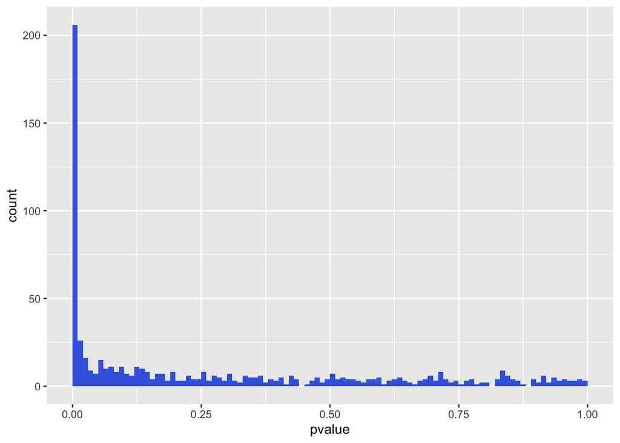

```r
ggplot(as(DE_results, "data.frame"), aes(x = pvalue)) + geom_histogram(binwidth = 0.01,
    fill = "Royalblue", boundary = 0)
```

**Figure 7:** distribution of pvalues from DE results

### Save tables with results stored in the DE_results_list object

```r
for (example_name in names(DE_results_list)) {
    # Save results table into a file
    write.table(x = as.data.frame(DE_results_list[[example_name]]), file = paste0(DE_path,
        "/DE_", example_name, ".txt"), sep = "\t", col.names = NA)
}
```

# Ste12

### Keep ste12 samples

```r
# Keep only WT-specific data to match Amanda's code inputs
keep <- metadata.all$genotype == "ste12"
metadata <- metadata.all[keep, ]
read_counts <- read_counts.all[, keep]
```

### DE analysis with DESeq2

```r
# Create folder for storing plots
plot_path <- paste0("./", mapper, "/Plots_intergenic_ste12")
DE_path <- paste0("./", mapper, "/DE_intergenic_ste12")
dir.create(path = plot_path, showWarnings = FALSE, recursive = TRUE)
dir.create(path = DE_path, showWarnings = FALSE, recursive = TRUE)

# Add extra metadata column with treatment and genotype data combined
metadata$treat_geno <- paste(metadata$treatment, metadata$genotype, sep = "_")

# Create DESeq2 object
dds <- DESeqDataSetFromMatrix(countData = read_counts, colData = metadata, design = ~experiment +
    treat_geno)  # Here we assume that all genotypes respond the same to treatment


# Make sure reference groups are 'none' and 'wt'. This means those categories
# will be the denominator when calculating Log2FC.
dds$treatment <- relevel(dds$treatment, "none")
# dds$genotype <- relevel(dds$genotype, 'wt')
dds$treat_geno <- relevel(dds$treat_geno, "none_ste12")
dds <- DESeq(dds)
```

### Explortory analysis #1

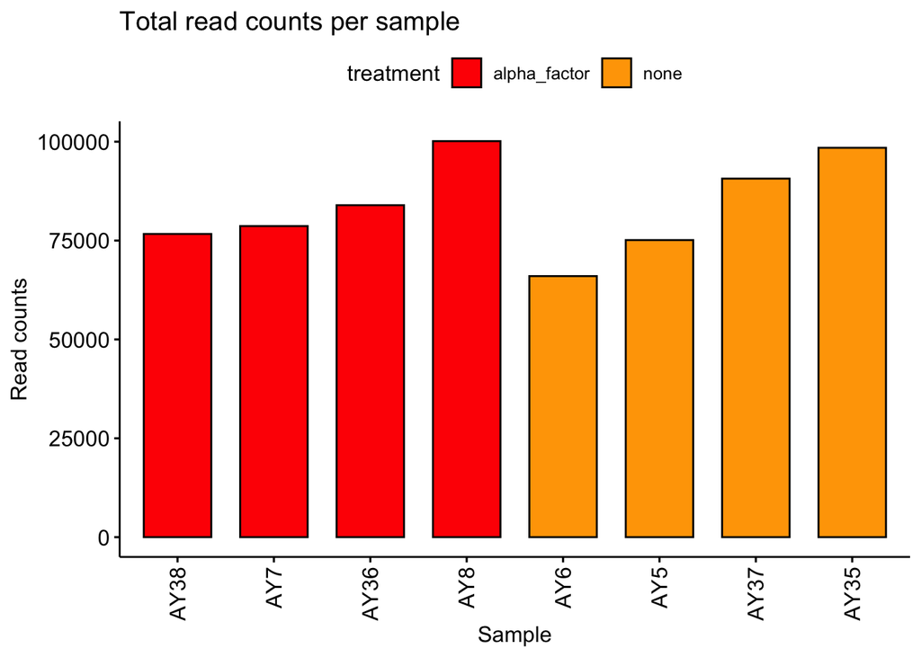

```r
# Plot total reads per sample using barchar
readcounts.p <- ggbarplot(data = metadata,
                x = "sample_id",
                y = "read_counts",
                x.text.angle = 90,
                fill = "treatment",
                title = "Total read counts per sample",
                ylab = "Read counts",
                sort.by.groups = TRUE,
                palette = c("red","orange"), #"jco",
                sort.val = "asc") + xlab("Sample") + ylab("Read counts")
ggsave2("barplot_read_counts_per_sample_intergenic.pdf", plot = readcounts.p, path = plot_path)

print(readcounts.p)
```

**Figure 1:** Number of reads per sample

### Preprocess data stored in DESeq2 object dds

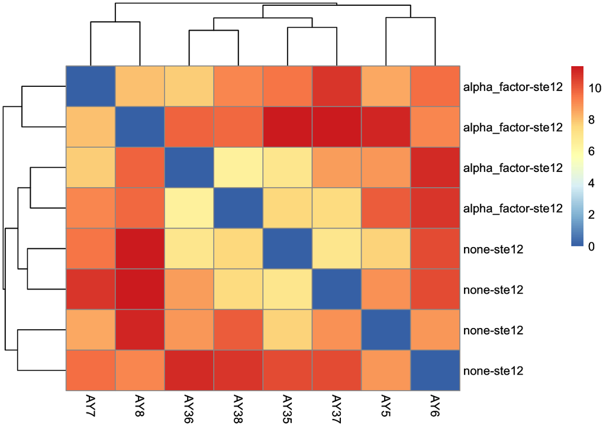

```r
# 1. Normalize counts dds.vst <- vst(dds, blind=TRUE)
dds.vst <- varianceStabilizingTransformation(dds)  # vst(dds, blind=TRUE) gives an error due to too few rows (<1000 in dds object)

# 2. Keep genes with at least 10 reads total across all samples
keep <- rowSums(as.data.frame(dds.vst@assays@data@listData)) >= 10
dds.vst <- dds.vst[keep, ]

# 3. Calculate distances between samples
sampleDists <- dist(t(assay(dds.vst)))

# 4. Plot inter-sample distances
sampleDistMatrix <- as.matrix(sampleDists)
rownames(sampleDistMatrix) <- paste(rownames(sampleDistMatrix), dds.vst$treatment)

# colnames(sampleDistMatrix) <- NULL
hm.p <- pheatmap(mat = sampleDistMatrix, clustering_distance_rows = sampleDists,
    clustering_distance_cols = sampleDists, labels_row = paste(metadata$treatment,
        metadata$genotype, sep = "-"), labels_col = metadata$sample_id)

ggsave2(filename = "heat_map_intergenc.pdf", plot = hm.p, path = plot_path)

print(hm.p)
```

### PCA

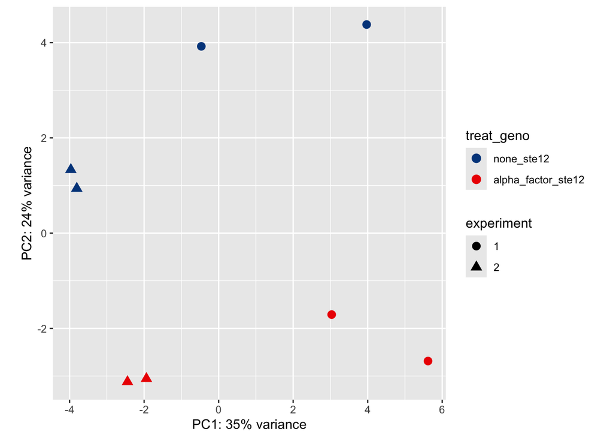

```r
# PCA
principal_components <- c(1, 2)
pca.p <- plot_PCA(object = dds.vst, ntop = 500, color_by = "treat_geno", shape_by = "experiment",
    pcs = principal_components, returnData = FALSE)

ggsave(paste("pca_by_group_PC", principal_components[1], principal_components[2],
    "_intergenic.pdf"), plot = pca.p, path = plot_path)
print(pca.p)
```

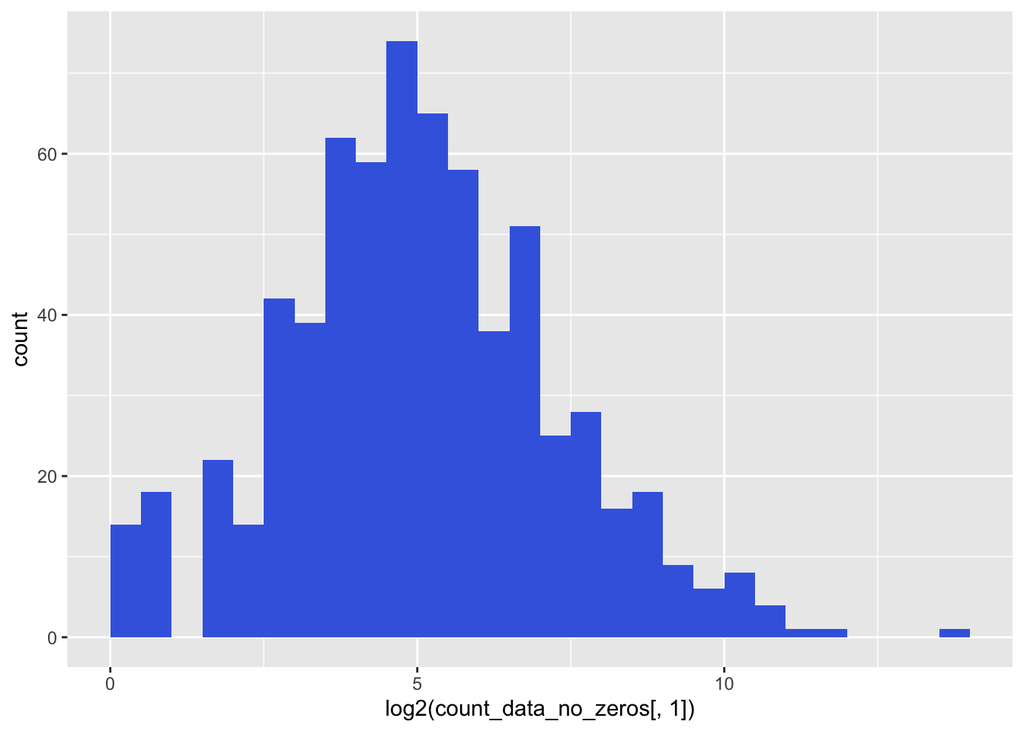

```r
count_data <- read_counts[, 3]
count_data_no_zeros <- as.data.frame(count_data[count_data > 0])

ggplot(count_data_no_zeros, aes(x = log2(count_data_no_zeros[, 1]))) + geom_histogram(binwidth = 0.5,
    fill = "Royalblue", boundary = 0)  # +   xlim(0,1000)
```

**Figure 4:** Read counts per intergenic region follows a negative binomial distribution.

### Print DESeq2 coefficients

```r
print(resultsNames(dds))
```

```
## [1] "Intercept"
## [2] "experiment_2_vs_1"
## [3] "treat_geno_alpha_factor_ste12_vs_none_ste12"
```

*Note: For additional information about different ways of extracting results from a DESeq object see results() function help by typing ?results in the console,*

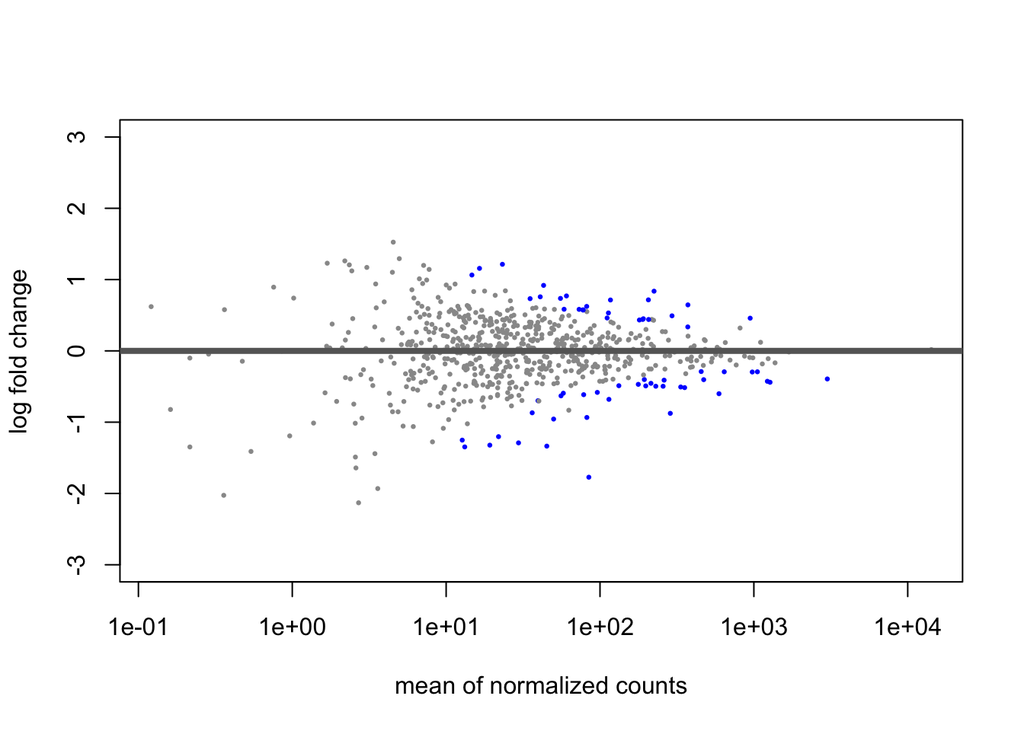

```r
# Create results directory where to store result tables
coef <- c("treat_geno_alpha_factor_ste12_vs_none_ste12")

# Set coef_id with the DESeq2 coefficient of interest
coef_id <- "af_vs_none_ste12"

# Get DESeq2 results. Note that when using coefficient names, you have to
# convert the coef vector to a list by doing list(c(coef))
DE_results <- results(dds, contrast = list(c(coef)))


plotMA(DE_results, ylim = c(-3, 3))
```

**Figure 5:** MA plot before shrinkage

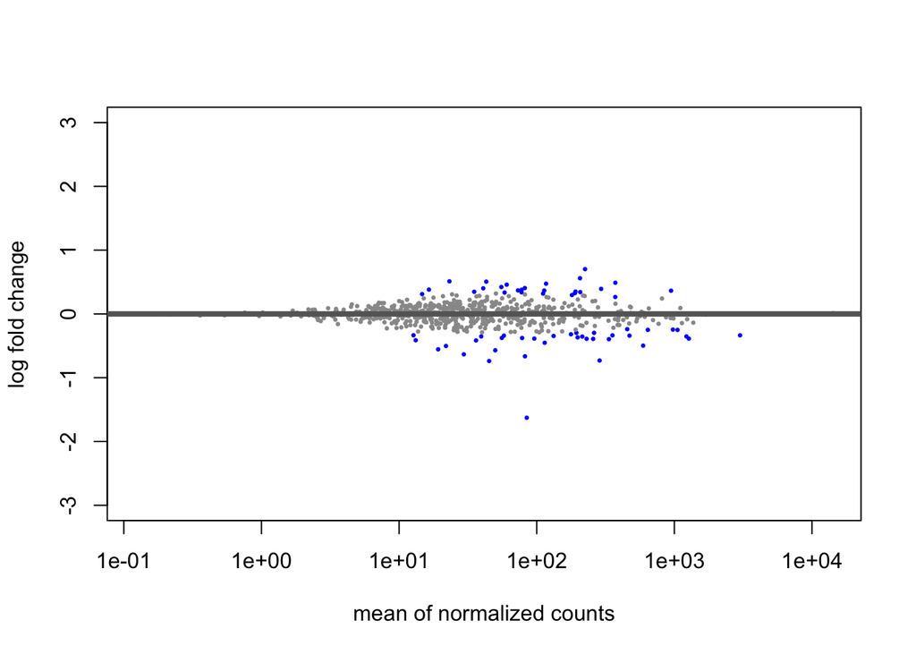

```r
# Shrink Log2FC of genes with low expression
DE_results <- lfcShrink(dds, contrast = list(c(coef)), type = "ashr", res = DE_results)

# Sort table by adjusted p,value (ascending)
DE_results <- DE_results[order(DE_results$padj), ]

plotMA(DE_results, ylim = c(-3, 3))
```

```r
# Add gene names to results table DE_results$gene_names <-
# get_gene_names_from_gene_ids(ensemble_ids = rownames(DE_results),
# annotation_db = org.Sc.sgd.db, look_for = 'ENSEMBL', fetch = 'GENENAME')
DE_results <- add_flanking_genes(summary_table = as.data.frame(DE_results))

# Store results table into DE_results list
DE_results_list[[coef_id]] <- DE_results

# Plot top10 diff expressed genes
plot_expression_topN_genes(DE_results_list[[coef_id]], N = 20)
```

```
## [1] "MSTRG.1"
## [1] "MSTRG.10"
## [1] "MSTRG.100"
## [1] "MSTRG.101"
## [1] "MSTRG.102"
## [1] "MSTRG.103"
## [1] "MSTRG.104"
## [1] "MSTRG.105"
## [1] "MSTRG.106"
## [1] "MSTRG.107"
## [1] "MSTRG.108"
## [1] "MSTRG.109"
## [1] "MSTRG.11"
## [1] "MSTRG.110"
## [1] "MSTRG.111"
## [1] "MSTRG.112"
## [1] "MSTRG.113"
## [1] "MSTRG.114"
## [1] "MSTRG.115"
## [1] "MSTRG.116"
```

```r
summary(DE_results, alpha = 0.05)
```

```
##   Row.names            baseMean        log2FoldChange           lfcSE
##  Length:684         Min.   :    0.00   Min.   :-1.6276562   Min.   :0.07396
##  Class :AsIs        1st Qu.:   11.96   1st Qu.:-0.0889378   1st Qu.:0.15610
##  Mode  :character   Median :   26.53   Median : 0.0002024   Median :0.19844
##                     Mean   :  120.34   Mean   :-0.0068642   Mean   :0.19155
##                     3rd Qu.:   78.12   3rd Qu.: 0.0888307   3rd Qu.:0.22642
##                     Max.   :14240.15   Max.   : 0.7020005   Max.   :0.36031
##
##      pvalue            padj         chromosome             db
##  Min.   :0.0000   Min.   :0.0000   Length:684         Length:684
##  1st Qu.:0.1292   1st Qu.:0.3735   Class :character   Class :character
##  Median :0.3615   Median :0.6248   Mode  :character   Mode  :character
##  Mean   :0.4189   Mean   :0.5995
##  3rd Qu.:0.6812   3rd Qu.:0.8741
##  Max.   :0.9998   Max.   :0.9998
##  NA's   :2        NA's   :135
##      type                end5              end3            strand
##  Length:684         Min.   :      4   Min.   :    573   Length:684
##  Class :character   1st Qu.: 141938   1st Qu.: 142601   Class :character
##  Mode  :character   Median : 363871   Median : 364482   Mode  :character
##                     Mean   : 427048   Mean   : 427968
##                     3rd Qu.: 652447   3rd Qu.: 654942
##                     Max.   :1521095   Max.   :1522648
##
##   gene_id_up         strand_up         gene_id_down       strand_down
##  Length:684         Length:684         Length:684         Length:684
##  Class :character   Class :character   Class :character   Class :character
##  Mode  :character   Mode  :character   Mode  :character   Mode  :character
##
##
##
##
##  up_gene_name       down_gene_name
##  Length:684         Length:684
##  Class :character   Class :character
##  Mode  :character   Mode  :character
##
##
##
##
```

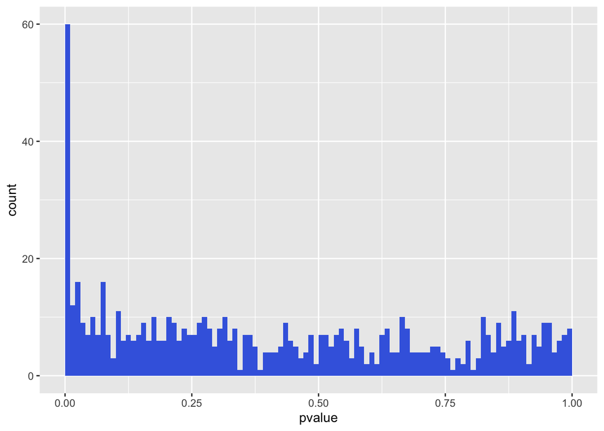

```r
ggplot(as(DE_results, "data.frame"), aes(x = pvalue)) + geom_histogram(binwidth = 0.01,
    fill = "Royalblue", boundary = 0)
```

**Figure 7:** distribution of pvalues from DE results

### Save tables with results stored in the DE_results_list object

```r
for (example_name in names(DE_results_list)) {
    # Save results table into a file
    write.table(x = as.data.frame(DE_results_list[[example_name]]), file = paste0(DE_path,
        "/DE_", example_name, ".txt"), sep = "\t", col.names = NA)
}
```

#### Functional analysis of DE resutls

1. Functions for finctional analysis

```r
dir.create(path = "./no_multimapper/GO_annotation", showWarnings = F)
dir.create(path = "./no_multimapper/GO_overrepresentation", showWarnings = F)
dir.create(path = "./no_multimapper/GO_gsea", showWarnings = F)

geneID_2_geneName <- function(gene_ids) {
    # Split gene ids string into individual ensembl acc ids
    gene_list <- stringr::str_split_1(string = gene_ids, pattern = "/")

    # Get gene names from a list of gene ids
    if (!identical(gene_list, "")) {
        gene_names <- get_gene_names_from_gene_ids(ensemble_ids = gene_list, annotation_db = org.Sc.sgd.db,
            look_for = "ENSEMBL", fetch = "GENENAME", return_all = TRUE)
        gene_list <- paste0(gene_names, collapse = "/")
    }

    # Concatenate gene names
    return(gene_list)
}


run_go_annotation <- function(gene_list, ontology = "BP", level = 3) {
    # Fetch GO gene annotations
    go.annot <- groupGO(keyType = "ENSEMBL", gene = gene_list, OrgDb = org.Sc.sgd.db,
        ont = ontology, level = level, readable = FALSE)  # org.Sc.sgd.db incompatible with this function (SYMBOL col is names GENENAME)

    # add gene names to output
    gene_id_list <- go.annot@result$geneID
    go.annot@result$gene_name <- unlist(lapply(gene_id_list, FUN = "geneID_2_geneName"))
    go.annot@result <- subset(go.annot, go.annot@result$Count > 0)

    # Order by decreasing gene counts
    go.annot@result <- go.annot@result[order(go.annot@result$Count, decreasing = TRUE),
        ]

    return(go.annot)
    # x <- subset(go.annot@result, Count > 0) return(x[order(x$Count,
    # decreasing = TRUE),])
}

run_go_overrepresentation <- function(gene_list, ontology = "BP") {
    # Fetch GO gene annotations
    go.ora <- enrichGO(keyType = "ENSEMBL", gene = gene_list, OrgDb = org.Sc.sgd.db,
        ont = ontology, minGSSize = 10, maxGSSize = 500, readable = FALSE)  # org.Sc.sgd.db incompatible with this function (SYMBOL col is names GENENAME)

    # add gene names to output
    gene_id_list <- go.ora@result$geneID
    go.ora@result$gene_name <- unlist(lapply(gene_id_list, FUN = "geneID_2_geneName"))
    go.ora@result <- subset(go.ora@result, go.ora@result$Count > 0)

    # Order by decreasing gene counts
    go.ora@result <- go.ora@result[order(go.ora@result$Count, decreasing = TRUE),
        ]

    return(go.ora)
    # x <- subset(go.annot@result, Count > 0) return(x[order(x$Count,
    # decreasing = TRUE),])
}
```

2. GO annotation / overrepresentation analysis for genes with padj <= 0.05 & abs(Log2FC) >= 1

```r
# ------------------- af_vs_none_wt # -------------------

af_vs_none_wt.df <- DE_results_list$af_vs_none_wt[order(DE_results_list$af_vs_none_wt$padj),
    ]
af_vs_none_wt.df.sig <- subset(af_vs_none_wt.df, padj <= 0.05 & abs(log2FoldChange) >=
    1)

# GO annotation
af_vs_none_wt.go_annot <- run_go_annotation(gene_list = c(af_vs_none_wt.df.sig$gene_id_up,
    af_vs_none_wt.df.sig$gene_id_down))

# GO Overrepresentation analysis
af_vs_none_wt.go_ora <- run_go_overrepresentation(gene_list = c(af_vs_none_wt.df.sig$gene_id_up,
    af_vs_none_wt.df.sig$gene_id_down))

# ------------------- af_vs_none_kar4 # -------------------

af_vs_none_kar4.df <- DE_results_list$af_vs_none_kar4[order(DE_results_list$af_vs_none_kar4$padj),
    ]
af_vs_none_kar4.df.sig <- subset(af_vs_none_kar4.df, padj <= 0.05 & abs(log2FoldChange) >=
    1)

# GO annotation
af_vs_none_kar4.go_annot <- run_go_annotation(gene_list = c(af_vs_none_kar4.df.sig$gene_id_up,
    af_vs_none_kar4.df.sig$gene_id_down), level = 5)

# GO Overrepresentation analysis
af_vs_none_kar4.go_ora <- run_go_overrepresentation(gene_list = c(af_vs_none_kar4.df.sig$gene_id_up,
    af_vs_none_kar4.df.sig$gene_id_down))


# ------------------- af_vs_none_ste12 # -------------------

af_vs_none_ste12.df <- DE_results_list$af_vs_none_ste12[order(DE_results_list$af_vs_none_ste12$padj),
    ]
af_vs_none_ste12.df.sig <- subset(af_vs_none_ste12.df, padj <= 0.05 & abs(log2FoldChange) >=
    1)

# GO annotation
af_vs_none_ste12.go_annot <- run_go_annotation(gene_list = c(af_vs_none_ste12.df.sig$gene_id_up,
    af_vs_none_ste12.df.sig$gene_id_down))

# GO Overrepresentation analysis
af_vs_none_ste12.go_ora <- run_go_overrepresentation(gene_list = c(af_vs_none_ste12.df.sig$gene_id_up,
    af_vs_none_ste12.df.sig$gene_id_down))
```

# Compare results between WT and kar4 / ste12

```r
dir.create(path = "./no_multimapper/Comparison_DE_GO", showWarnings = FALSE, recursive = TRUE)

# Merge DE_result wt vs kar4 df
wt_kar4.merged <- merge(x = as.data.frame(DE_results_list[["af_vs_none_wt"]]), y = as.data.frame(DE_results_list[["af_vs_none_kar4"]]),
    by = "row.names", all = TRUE)

head(wt_kar4.merged)
```

```
##   Row.names Row.names.x baseMean.x log2FoldChange.x   lfcSE.x   pvalue.x
## 1   MSTRG.1     MSTRG.1  18.956569       0.28279043 0.2934634 0.14451054
## 2  MSTRG.10    MSTRG.10  24.334422      -0.32308335 0.2615936 0.08203071
## 3 MSTRG.100   MSTRG.100   9.932835      -0.33803323 0.3706062 0.11738577
## 4 MSTRG.101   MSTRG.101   3.512679      -0.33182355 0.5305770 0.17472469
## 5 MSTRG.102   MSTRG.102  71.861531      -0.09291308 0.1685521 0.51937720
## 6 MSTRG.103   MSTRG.103  16.143599       0.40549997 0.3337830 0.05500610
##      padj.x chromosome.x      db.x     type.x end5.x end3.x strand.x
## 1 0.3173315            I StringTie transcript   3146   6318        -
## 2 0.2146470            I StringTie transcript  69700  71345        -
## 3 0.2730306           IV StringTie transcript 470703 471523        -
## 4 0.3657570           IV StringTie transcript 476825 477287        +
## 5 0.7446778           IV StringTie transcript 505448 507843        -
## 6 0.1614198           IV StringTie transcript 538977 539602        -
##   gene_id_up.x strand_up.x gene_id_down.x strand_down.x up_gene_name.x
```

[output cut: 34 more lines]

```r
# Upregulated in WT and not in kar4
wt_UP_kar4_NC <- subset(wt_kar4.merged, log2FoldChange.x > 1 & log2FoldChange.y <
    0.3 & padj.x < 0.05)

# Upregulated in kar4 and not in WT
wt_NC_kar4_UP <- subset(wt_kar4.merged, log2FoldChange.y > 1 & log2FoldChange.x <
    0.3 & padj.y < 0.05)

# Downregulated in WT and not in kar4
wt_DN_kar4_NC <- subset(wt_kar4.merged, log2FoldChange.x < -1 & log2FoldChange.y >
    -0.3 & padj.x < 0.05)

# Upregulated in kar4 and not in WT
wt_NC_kar4_DN <- subset(wt_kar4.merged, log2FoldChange.y < -1 & log2FoldChange.x >
    -0.3 & padj.y < 0.05)


write.table(x = wt_UP_kar4_NC, file = "./no_multimapper/Comparison_DE_GO/wt_UP_kar4_NC.txt",
    sep = "\t", col.names = NA)
write.table(x = wt_NC_kar4_UP, file = "./no_multimapper/Comparison_DE_GO/wt_NC_kar4_UP.txt",
    sep = "\t", col.names = NA)
write.table(x = wt_DN_kar4_NC, file = "./no_multimapper/Comparison_DE_GO/wt_DN_kar4_NC.txt",
    sep = "\t", col.names = NA)
write.table(x = wt_NC_kar4_DN, file = "./no_multimapper/Comparison_DE_GO/wt_NC_kar4_DN.txt",
    sep = "\t", col.names = NA)


# Merge DE_result wt vs ste12 df
wt_ste12.merged <- merge(x = as.data.frame(DE_results_list[["af_vs_none_wt"]]), y = as.data.frame(DE_results_list[["af_vs_none_ste12"]]),
    by = "row.names", all = TRUE)

# Upregulated in WT and not in ste12
wt_UP_ste12_NC <- subset(wt_ste12.merged, log2FoldChange.x > 1 & log2FoldChange.y <
    0.3 & padj.x < 0.05)

# Upregulated in ste12 and not in WT
wt_NC_ste12_UP <- subset(wt_ste12.merged, log2FoldChange.y > 1 & log2FoldChange.x <
    0.3 & padj.y < 0.05)

# Downregulated in WT and not in ste12
wt_DN_ste12_NC <- subset(wt_ste12.merged, log2FoldChange.x < -1 & log2FoldChange.y >
    -0.3 & padj.x < 0.05)

# Upregulated in ste12 and not in WT
wt_NC_ste12_DN <- subset(wt_ste12.merged, log2FoldChange.y < -1 & log2FoldChange.x >
    -0.3 & padj.y < 0.05)


write.table(x = wt_UP_ste12_NC, file = "./no_multimapper/Comparison_DE_GO/wt_UP_ste12_NC.txt",
    sep = "\t", col.names = NA)
write.table(x = wt_NC_ste12_UP, file = "./no_multimapper/Comparison_DE_GO/wt_NC_ste12_UP.txt",
    sep = "\t", col.names = NA)
write.table(x = wt_DN_ste12_NC, file = "./no_multimapper/Comparison_DE_GO/wt_DN_ste12_NC.txt",
    sep = "\t", col.names = NA)
write.table(x = wt_NC_ste12_DN, file = "./no_multimapper/Comparison_DE_GO/wt_NC_ste12_DN.txt",
    sep = "\t", col.names = NA)
```

#### Summarize comparative DE data

```r
select_columns <- c("Row.names", "baseMean.x", "log2FoldChange.x", "padj.x", "baseMean.y",
    "log2FoldChange.y", "padj.y")

wt_UP_kar4_NC.summary <- dplyr::select(wt_UP_kar4_NC, select_columns)
wt_UP_kar4_NC.summary$igv <- wt_UP_kar4_NC.summary$Row.names %>%
    stringr::str_remove(pattern = "intergenic_") %>%
    stringr::str_replace(pattern = "_", replacement = ":") %>%
    stringr::str_replace(pattern = "_", replacement = "-")

wt_NC_kar4_UP.summary <- dplyr::select(wt_NC_kar4_UP, select_columns)
wt_NC_kar4_UP.summary$igv <- wt_NC_kar4_UP.summary$Row.names %>%
    stringr::str_remove(pattern = "intergenic_") %>%
    stringr::str_replace(pattern = "_", replacement = ":") %>%
    stringr::str_replace(pattern = "_", replacement = "-")

wt_DN_kar4_NC.summary <- dplyr::select(wt_DN_kar4_NC, select_columns)
wt_DN_kar4_NC.summary$igv <- wt_DN_kar4_NC.summary$Row.names %>%
    stringr::str_remove(pattern = "intergenic_") %>%
    stringr::str_replace(pattern = "_", replacement = ":") %>%
    stringr::str_replace(pattern = "_", replacement = "-")

wt_NC_kar4_DN.summary <- dplyr::select(wt_NC_kar4_DN, select_columns)
wt_NC_kar4_DN.summary$igv <- wt_NC_kar4_DN.summary$Row.names %>%
    stringr::str_remove(pattern = "intergenic_") %>%
    stringr::str_replace(pattern = "_", replacement = ":") %>%
    stringr::str_replace(pattern = "_", replacement = "-")

dim(wt_UP_kar4_NC.summary)
```

```
## [1] 6 8
```

```r
dim(wt_NC_kar4_UP.summary)
```

```
## [1] 21  8
```

```r
dim(wt_DN_kar4_NC.summary)
```

```
## [1] 4 8
```

```r
dim(wt_NC_kar4_DN.summary)
```

```
## [1] 4 8
```

#### Prepare gene lists for enrichment analysis

```r
wt_UP_kar4_NC.summary <- add_flanking_genes(summary_table = wt_UP_kar4_NC.summary)
wt_NC_kar4_UP.summary <- add_flanking_genes(summary_table = wt_NC_kar4_UP.summary)
wt_DN_kar4_NC.summary <- add_flanking_genes(summary_table = wt_DN_kar4_NC.summary)
wt_NC_kar4_DN.summary <- add_flanking_genes(summary_table = wt_NC_kar4_DN.summary)

write.table(x = wt_UP_kar4_NC.summary, file = "./no_multimapper/Comparison_DE_GO/wt_UP_kar4_NC.summary.txt",
    sep = "\t", col.names = NA)
write.table(x = wt_NC_kar4_UP.summary, file = "./no_multimapper/Comparison_DE_GO/wt_NC_kar4_UP.summary.txt",
    sep = "\t", col.names = NA)
write.table(x = wt_DN_kar4_NC.summary, file = "./no_multimapper/Comparison_DE_GO/wt_DN_kar4_NC.summary.txt",
    sep = "\t", col.names = NA)
write.table(x = wt_NC_kar4_DN.summary, file = "./no_multimapper/Comparison_DE_GO/wt_NC_kar4_DN.summary.txt",
    sep = "\t", col.names = NA)
```

#### Functional analysis of flanking genes

```r
# ------------------------------- wt vs kar4 ------------------------------- GO
# annotation
wt_UP_kar4_NC.summary.go_annot <- run_go_annotation(gene_list = c(wt_UP_kar4_NC.summary$gene_id_up,
    wt_UP_kar4_NC.summary$gene_id_down))
write.table(x = as.data.frame(wt_UP_kar4_NC.summary.go_annot), file = "./no_multimapper/Comparison_DE_GO/wt_UP_kar4_NC.summary.go_annot.txt",
    sep = "\t", col.names = NA)

wt_NC_kar4_UP.summary.go_annot <- run_go_annotation(gene_list = c(wt_NC_kar4_UP.summary$gene_id_up,
    wt_NC_kar4_UP.summary$gene_id_down))
write.table(x = as.data.frame(wt_NC_kar4_UP.summary.go_annot), file = "./no_multimapper/Comparison_DE_GO/wt_NC_kar4_UP.summary.go_annot.txt",
    sep = "\t", col.names = NA)


wt_DN_kar4_NC.summary.go_annot <- run_go_annotation(gene_list = c(wt_DN_kar4_NC.summary$gene_id_up,
    wt_DN_kar4_NC.summary$gene_id_down))
write.table(x = as.data.frame(wt_DN_kar4_NC.summary.go_annot), file = "./no_multimapper/Comparison_DE_GO/wt_DN_kar4_NC.summary.go_annot.txt",
    sep = "\t", col.names = NA)

wt_NC_kar4_DN.summary.go_annot <- run_go_annotation(gene_list = c(wt_NC_kar4_DN.summary$gene_id_up,
    wt_NC_kar4_DN.summary$gene_id_down))
write.table(x = as.data.frame(wt_NC_kar4_DN.summary.go_annot), file = "./no_multimapper/Comparison_DE_GO/wt_NC_kar4_DN.summary.go_annot.txt",
    sep = "\t", col.names = NA)

# Go Overrepresentation analysis
wt_UP_kar4_NC.summary.go_ora <- run_go_overrepresentation(gene_list = c(wt_UP_kar4_NC.summary$gene_id_up,
    wt_UP_kar4_NC.summary$gene_id_down))
write.table(x = as.data.frame(wt_UP_kar4_NC.summary.go_ora), file = "./no_multimapper/Comparison_DE_GO/wt_UP_kar4_NC.summary.go_ora.txt",
    sep = "\t", col.names = NA)

wt_NC_kar4_UP.summary.go_ora <- run_go_overrepresentation(gene_list = c(wt_NC_kar4_UP.summary$gene_id_up,
    wt_NC_kar4_UP.summary$gene_id_down))
write.table(x = as.data.frame(wt_NC_kar4_UP.summary.go_ora), file = "./no_multimapper/Comparison_DE_GO/wt_NC_kar4_UP.summary.go_ora.txt",
    sep = "\t", col.names = NA)

wt_DN_kar4_NC.summary.go_ora <- run_go_overrepresentation(gene_list = c(wt_DN_kar4_NC.summary$gene_id_up,
    wt_DN_kar4_NC.summary$gene_id_down))
write.table(x = as.data.frame(wt_DN_kar4_NC.summary.go_ora), file = "./no_multimapper/Comparison_DE_GO/wt_DN_kar4_NC.summary.go_ora.txt",
    sep = "\t", col.names = NA)

wt_NC_kar4_DN.summary.go_ora <- run_go_overrepresentation(gene_list = c(wt_NC_kar4_DN.summary$gene_id_up,
    wt_NC_kar4_DN.summary$gene_id_down))
write.table(x = as.data.frame(wt_NC_kar4_DN.summary.go_ora), file = "./no_multimapper/Comparison_DE_GO/wt_NC_kar4_DN.summary.go_ora.txt",
    sep = "\t", col.names = NA)

# ------------------------------- wt vs ste12 -------------------------------

# GO annotation
wt_UP_ste12_NC.summary.go_annot <- run_go_annotation(gene_list = c(wt_UP_ste12_NC$gene_id_up.x,
    wt_UP_ste12_NC$gene_id_down.x))
write.table(x = as.data.frame(wt_NC_kar4_DN.summary.go_ora), file = "./no_multimapper/Comparison_DE_GO/wt_NC_kar4_DN.summary.go_ora.txt",
    sep = "\t", col.names = NA)

wt_NC_ste12_UP.summary.go_annot <- run_go_annotation(gene_list = c(wt_NC_ste12_UP$gene_id_up.x,
    wt_NC_ste12_UP$gene_id_down.x))
write.table(x = as.data.frame(wt_NC_kar4_DN.summary.go_ora), file = "./no_multimapper/Comparison_DE_GO/wt_NC_kar4_DN.summary.go_ora.txt",
    sep = "\t", col.names = NA)

wt_DN_ste12_NC.summary.go_annot <- run_go_annotation(gene_list = c(wt_DN_ste12_NC$gene_id_up.x,
    wt_DN_ste12_NC$gene_id_down.x))
write.table(x = as.data.frame(wt_NC_kar4_DN.summary.go_ora), file = "./no_multimapper/Comparison_DE_GO/wt_NC_kar4_DN.summary.go_ora.txt",
    sep = "\t", col.names = NA)

wt_NC_ste12_DN.summary.go_annot <- run_go_annotation(gene_list = c(wt_NC_ste12_DN$gene_id_up.x,
    wt_NC_ste12_DN$gene_id_down.x))
write.table(x = as.data.frame(wt_NC_kar4_DN.summary.go_ora), file = "./no_multimapper/Comparison_DE_GO/wt_NC_kar4_DN.summary.go_ora.txt",
    sep = "\t", col.names = NA)

# Go Overrepresentation analysis
wt_UP_ste12_NC.summary.go_ora <- run_go_overrepresentation(gene_list = c(wt_UP_ste12_NC$gene_id_up.x,
    wt_UP_ste12_NC$gene_id_down.x))
write.table(x = as.data.frame(wt_UP_ste12_NC.summary.go_ora), file = "./no_multimapper/Comparison_DE_GO/wt_UP_ste12_NC.summary.go_ora.txt",
    sep = "\t", col.names = NA)

wt_NC_ste12_UP.summary.go_ora <- run_go_overrepresentation(gene_list = c(wt_UP_ste12_NC$gene_id_up.x,
    wt_UP_ste12_NC$gene_id_down.x))
write.table(x = as.data.frame(wt_NC_ste12_UP.summary.go_ora), file = "./no_multimapper/Comparison_DE_GO/wt_NC_ste12_UP.summary.go_ora.txt",
    sep = "\t", col.names = NA)

wt_DN_ste12_NC.summary.go_ora <- run_go_overrepresentation(gene_list = c(wt_UP_ste12_NC$gene_id_up.x,
    wt_UP_ste12_NC$gene_id_down.x))
write.table(x = as.data.frame(wt_DN_ste12_NC.summary.go_ora), file = "./no_multimapper/Comparison_DE_GOwt_DN_ste12_NC.summary.go_ora.txt",
    sep = "\t", col.names = NA)

wt_NC_ste12_DN.summary.go_ora <- run_go_overrepresentation(gene_list = c(wt_UP_ste12_NC$gene_id_up.x,
    wt_UP_ste12_NC$gene_id_down.x))
write.table(x = as.data.frame(wt_NC_ste12_DN.summary.go_ora), file = "./no_multimapper/Comparison_DE_GO/wt_NC_ste12_DN.summary.go_ora.txt",
    sep = "\t", col.names = NA)
```

#### Comparative Venn diagrams

```r
library(VennDiagram)

# Helper function to display Venn diagram
display_venn <- function(x, ...) {
    grid.newpage()
    venn_object <- venn.diagram(x, ...)
    # grid.draw(venn_object)
    return(venn_object)
}

# Upregulated genes
de.wt <- DE_results_list$af_vs_none_wt
de.kar4 <- DE_results_list$af_vs_none_kar4
de.ste12 <- DE_results_list$af_vs_none_ste12

# Genes upregulated
comp.up <- list(WT = rownames(subset(de.wt, log2FoldChange >= 1 & padj <= 0.05)),
    Kar4 = rownames(subset(de.kar4, log2FoldChange >= 1 & padj <= 0.05)), Ste12 = rownames(subset(de.ste12,
        log2FoldChange >= 1 & padj <= 0.05)))

p.venn.up <- display_venn(comp.up, fill = c("#E69F00", "#56B4E9", "#009E73"), lwd = 2,
    lty = "blank", cex = 2, fontface = "italic", cat.cex = 1, cat.fontface = "bold",
    cat.default.pos = "outer", main = "Upregulated predicted intergenic transcripts (AF vs None)",
    main.fontface = "bold", filename = "./no_multimapper/Comparison_DE_GO/comp_venn_up.png")


# Genes downregulated
comp.down <- list(WT = rownames(subset(de.wt, log2FoldChange <= -1 & padj <= 0.05)),
    Kar4 = rownames(subset(de.kar4, log2FoldChange <= -1 & padj <= 0.05)), Ste12 = rownames(subset(de.ste12,
        log2FoldChange <= -1 & padj <= 0.05)))

p.venn.down <- display_venn(comp.down, fill = c("#E69F00", "#56B4E9", "#009E73"),
    lwd = 2, lty = "blank", cex = 2, fontface = "italic", cat.cex = 1, cat.fontface = "bold",
    cat.default.pos = "outer", main = "Downregulated predicted intergenic transcripts (AF vs None)",
    main.fontface = "bold", filename = "./no_multimapper/Comparison_DE_GO/comp_venn_down.png")


comp.table <- as.data.frame(cbind(subset(as.data.frame(summary(comp.up)), Var2 ==
    "Length")[c(1, 3)], subset(as.data.frame(summary(comp.down)), Var2 == "Length")[c(3)]))
colnames(comp.table) <- c("genotype", "upregulated", "downregulated")

p.venn.up
```

```
## [1] 1
```

```r
p.venn.down
```

```
## [1] 1
```

#### Try GO slim approach

```r
library(GSEABase)
```

### TPM expression profiles of intergenic regions and its comparison with a similar profile from the protein-coding genes.

```r
intergenic_transcripts.length <- read_counts.star["Length"]
read_counts.all
```

[output not shown]

[output cut: 1315 more lines]

[output not shown]

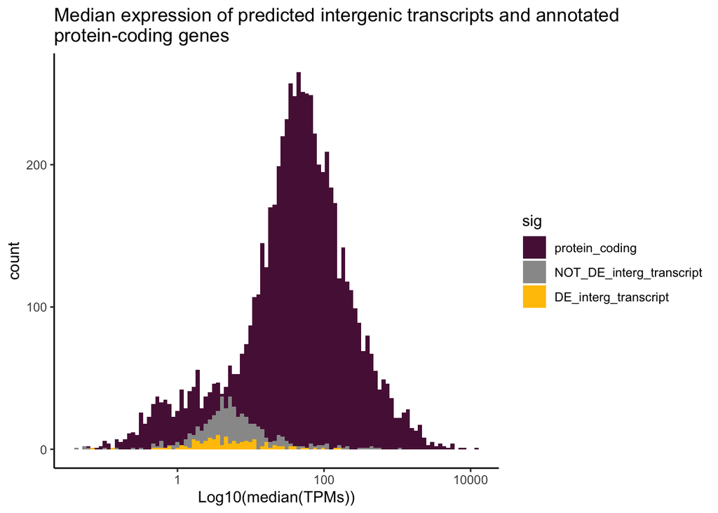

```r
# Load read count table from comp8901vs8345
read_counts.genes <- read.table(file = "../TK_76/read_counts_table_comp8901vs8345.txt",
                          header = TRUE, # First line contains column headers
                          row.names = 1, # Column 1 contains row names
                          sep = "\t")   # Column delimiter is a tab (\t)

# Round read counts to the closest integer
read_counts.genes <- round(read_counts.genes, digits = 0)


# Load annotation data
gene_length <- read.table(file = "./data/gene_length.txt", header = F, row.names = 1)
colnames(gene_length) <- "Length"

#########################################################################################
# Calculate TPMs on genes and ITs toether
#########################################################################################
read_counts.merged <- rbind(read_counts.all, read_counts.genes)
feature.length <- rbind(intergenic_transcripts.length, gene_length)

read_counts.merged.tpm <- normalize_by_TPM(
                          counts.df = read_counts.merged,
                          gene_length = feature.length)

data <- as.data.frame(rbind(
    cbind(
      TPMs=rowMedians(
        subset(read_counts.merged.tpm, rownames(read_counts.merged.tpm) %in% rownames(intergenic_transcripts.length))),
      annot="intergenic_transcripts",
      gene_id=rownames(subset(read_counts.merged.tpm, rownames(read_counts.merged.tpm) %in%
                       rownames(intergenic_transcripts.length)))
      ),
    cbind(TPMs=rowMedians(
        subset(read_counts.merged.tpm, rownames(read_counts.merged.tpm) %in% rownames(gene_length))),
      annot="genes",
      gene_id=rownames(subset(read_counts.merged.tpm, rownames(read_counts.merged.tpm) %in% rownames(gene_length)))
      )
    )
  )

data$TPMs <- as.numeric(data$TPMs)

data$sig <- 'protein_coding'
data$sig[which(data$gene_id %in% rownames(intergenic_transcripts.length))] <- 'NOT_DE_interg_transcript'


data$sig[which(data$gene_id %in% c(rownames(af_vs_none_wt.df.sig),
                                      rownames(af_vs_none_kar4.df.sig),
                                      rownames(af_vs_none_ste12.df.sig)))] <- 'DE_interg_transcript'

data$sig <- as.factor(data$sig)
data$sig <- factor(data$sig, levels = c('protein_coding',"NOT_DE_interg_transcript","DE_interg_transcript"))

hist.p <- ggplot(data, aes(x = TPMs, fill = sig)) +
  geom_histogram(position = "identity", alpha = 1, bins = 100 ) +
  labs( title = stringr::str_wrap("Median expression of predicted intergenic transcripts and annotated protein-coding genes", 80)) +
  theme_classic() + scale_x_log10() + xlab("Log10(median(TPMs))") + scale_fill_manual(values=c("#581845",'#999999','#FFC300'))


ggsave2(filename = "intergenic_vs_genes.histogram.pdf", plot = hist.p, path = "./no_multimapper/Plots_intergenic_wt/")

hist.p
```

```r
#########################################################################################
```

### Plot intergenic transcripts dispersion across chromsomes

```r
library(karyoploteR)

pdf(file = "./no_multimapper/Plots_intergenic_wt/IT_distribution_on_chromosomes.pdf")

# Load Sc genome
kp <- karyoploteR::plotKaryotype(genome = "sacCer3")

# Add chromosome coords
kpAddBaseNumbers(kp, tick.dist = 1e+05, units = "kb", tick.len = 10, tick.col = "red3",
    cex = 0.5, minor.tick.dist = 10000, minor.tick.len = 5, minor.tick.col = "gray2")



library(rtracklayer)

# Load intergenic transcripts as genes
features <- import(con = "./data/aymerge.no_LTR.NO_ref_genes_karyoploteR.gtf")
genes <- features[features$type == "transcript"]
kpPlotRegions(kp, data = genes, col = "green4")

# Load centromere coordinates
features <- import(con = "./data/centromeres.gff")
centromeres <- features[features$type == "centromere"]
kpPlotRegions(kp, data = centromeres, col = "red", num.layers = 2)

dev.off()
```

### Plot number of DE predicted ITs for each genotype

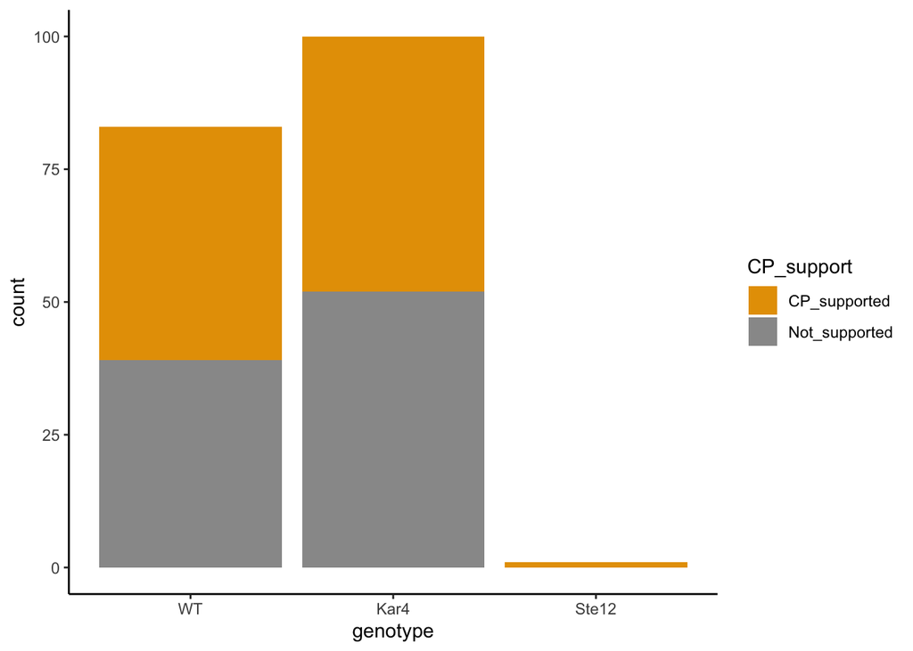

```r
# Load IDs or ITs supported by CPs (+/- 100bp)
ITs_supp_by_cp <- read.table(file = "./STRINGTIE/aymerge.no_LTR.NO_ref_genes_with_PROMOTERS_100bp_window.txt",
    header = F)

WT <- af_vs_none_wt.df.sig
WT$CP <- "Not_supported"
WT$CP[which(row.names(WT) %in% ITs_supp_by_cp$V1)] <- "CP_supported"

KAR4 <- af_vs_none_kar4.df.sig
KAR4$CP <- "Not_supported"
KAR4$CP[which(row.names(KAR4) %in% ITs_supp_by_cp$V1)] <- "CP_supported"

STE12 <- af_vs_none_ste12.df.sig
STE12$CP <- "Not_supported"
STE12$CP[which(row.names(STE12) %in% ITs_supp_by_cp$V1)] <- "CP_supported"

sig.data <- as.data.frame(cbind(genotype = "WT", CP_support = WT$CP))
sig.data <- rbind(sig.data, as.data.frame(cbind(genotype = "Kar4", CP_support = KAR4$CP)))
sig.data <- rbind(sig.data, as.data.frame(cbind(genotype = "Ste12", CP_support = STE12$CP)))
sig.data$genotype <- as.factor(sig.data$genotype)

# Sort levels so they are being shown in the correct order
sig.data$genotype <- factor(sig.data$genotype, levels = c("WT", "Kar4", "Ste12"))

# Plot bar plot
bar.p <- ggplot(sig.data, aes(genotype)) + geom_bar(aes(fill = CP_support)) + theme_classic() +
    scale_fill_manual(values = c("#E69F00", "#999999"))

ggsave2(filename = "./no_multimapper/Plots_intergenic_wt/sig.genes.pdf", plot = bar.p,
    width = 4, height = 4)
bar.p
```